# project data visualization (exploratory )

## Visualizing FordGoBike Data (2019)

### by Islam Muhammad

```python
%%HTML
<style type="text/css">
table.dataframe td, table.dataframe th {
    border: 1px  black solid !important;
    padding: 1px  black solid !important;
     color: black !important;
}
</style>
```

```python
# import all packages and set plots to be embedded inline
import numpy as np
import pandas as pd
import matplotlib.pyplot as plt
import seaborn as sns
sns.set()
import requests
%matplotlib inline
```

```python
# Download the "fordgobike-tripdata.csv" file programmatically
url = "https://video.udacity-data.com/topher/2020/October/5f91cf38_201902-fordgobike-tripdata/201902-fordgobike-tripdata.csv"
response = requests.get(url)
# save csv to file
with open('Downloads/data/Visualization/fordgobike-tripdata.csv', mode='wb') as file:
    file.write(response.content)
```

```python
# Loading dataset
url = 'Downloads/data/Visualization/fordgobike-tripdata.csv'
df_bike = pd.read_csv(url , sep=',', encoding='utf8')
df_bike.head(10)
```

|  | duration_sec | start_time | end_time | start_station_id | start_station_name | start_station_latitude | start_station_longitude | end_station_id | end_station_name | end_station_latitude | end_station_longitude | bike_id | user_type | member_birth_year | member_gender | bike_share_for_all_trip |
| --- | --- | --- | --- | --- | --- | --- | --- | --- | --- | --- | --- | --- | --- | --- | --- | --- |
| 0 | 52185 | 2019-02-28 17:32:10.1450 | 2019-03-01 08:01:55.9750 | 21.0 | Montgomery St BART Station (Market St at 2nd St) | 37.789625 | -122.400811 | 13.0 | Commercial St at Montgomery St | 37.794231 | -122.402923 | 4902 | Customer | 1984.0 | Male | No |
| 1 | 42521 | 2019-02-28 18:53:21.7890 | 2019-03-01 06:42:03.0560 | 23.0 | The Embarcadero at Steuart St | 37.791464 | -122.391034 | 81.0 | Berry St at 4th St | 37.775880 | -122.393170 | 2535 | Customer | NaN | NaN | No |
| 2 | 61854 | 2019-02-28 12:13:13.2180 | 2019-03-01 05:24:08.1460 | 86.0 | Market St at Dolores St | 37.769305 | -122.426826 | 3.0 | Powell St BART Station (Market St at 4th St) | 37.786375 | -122.404904 | 5905 | Customer | 1972.0 | Male | No |
| 3 | 36490 | 2019-02-28 17:54:26.0100 | 2019-03-01 04:02:36.8420 | 375.0 | Grove St at Masonic Ave | 37.774836 | -122.446546 | 70.0 | Central Ave at Fell St | 37.773311 | -122.444293 | 6638 | Subscriber | 1989.0 | Other | No |
| 4 | 1585 | 2019-02-28 23:54:18.5490 | 2019-03-01 00:20:44.0740 | 7.0 | Frank H Ogawa Plaza | 37.804562 | -122.271738 | 222.0 | 10th Ave at E 15th St | 37.792714 | -122.248780 | 4898 | Subscriber | 1974.0 | Male | Yes |
| 5 | 1793 | 2019-02-28 23:49:58.6320 | 2019-03-01 00:19:51.7600 | 93.0 | 4th St at Mission Bay Blvd S | 37.770407 | -122.391198 | 323.0 | Broadway at Kearny | 37.798014 | -122.405950 | 5200 | Subscriber | 1959.0 | Male | No |
| 6 | 1147 | 2019-02-28 23:55:35.1040 | 2019-03-01 00:14:42.5880 | 300.0 | Palm St at Willow St | 37.317298 | -121.884995 | 312.0 | San Jose Diridon Station | 37.329732 | -121.901782 | 3803 | Subscriber | 1983.0 | Female | No |
| 7 | 1615 | 2019-02-28 23:41:06.7660 | 2019-03-01 00:08:02.7560 | 10.0 | Washington St at Kearny St | 37.795393 | -122.404770 | 127.0 | Valencia St at 21st St | 37.756708 | -122.421025 | 6329 | Subscriber | 1989.0 | Male | No |
| 8 | 1570 | 2019-02-28 23:41:48.7900 | 2019-03-01 00:07:59.7150 | 10.0 | Washington St at Kearny St | 37.795393 | -122.404770 | 127.0 | Valencia St at 21st St | 37.756708 | -122.421025 | 6548 | Subscriber | 1988.0 | Other | No |
| 9 | 1049 | 2019-02-28 23:49:47.6990 | 2019-03-01 00:07:17.0250 | 19.0 | Post St at Kearny St | 37.788975 | -122.403452 | 121.0 | Mission Playground | 37.759210 | -122.421339 | 6488 | Subscriber | 1992.0 | Male | No |

```python
# sampling
df_bike.sample(10)
```

|  | duration_sec | start_time | end_time | start_station_id | start_station_name | start_station_latitude | start_station_longitude | end_station_id | end_station_name | end_station_latitude | end_station_longitude | bike_id | user_type | member_birth_year | member_gender | bike_share_for_all_trip |
| --- | --- | --- | --- | --- | --- | --- | --- | --- | --- | --- | --- | --- | --- | --- | --- | --- |
| 105407 | 470 | 2019-02-14 06:45:00.7090 | 2019-02-14 06:52:51.6750 | 30.0 | San Francisco Caltrain (Townsend St at 4th St) | 37.776598 | -122.395282 | 22.0 | Howard St at Beale St | 37.789756 | -122.394643 | 4358 | Subscriber | 1988.0 | Male | No |
| 138855 | 306 | 2019-02-08 04:09:26.5940 | 2019-02-08 04:14:32.9880 | 62.0 | Victoria Manalo Draves Park | 37.777791 | -122.406432 | 44.0 | Civic Center/UN Plaza BART Station (Market St ... | 37.781074 | -122.411738 | 674 | Subscriber | 1977.0 | Male | Yes |
| 42079 | 102 | 2019-02-22 17:59:21.1870 | 2019-02-22 18:01:03.6380 | 359.0 | Williams Ave at Apollo St | 37.730168 | -122.398963 | 358.0 | Williams Ave at 3rd St | 37.729279 | -122.392896 | 6587 | Subscriber | 1978.0 | Male | Yes |
| 29359 | 593 | 2019-02-25 07:30:23.6440 | 2019-02-25 07:40:16.9050 | 93.0 | 4th St at Mission Bay Blvd S | 37.770407 | -122.391198 | 22.0 | Howard St at Beale St | 37.789756 | -122.394643 | 4743 | Subscriber | 1987.0 | Male | No |
| 149179 | 344 | 2019-02-06 19:49:27.6480 | 2019-02-06 19:55:12.1290 | 258.0 | University Ave at Oxford St | 37.872355 | -122.266447 | 256.0 | Hearst Ave at Euclid Ave | 37.875112 | -122.260553 | 5053 | Subscriber | 1995.0 | Female | No |
| 2831 | 103 | 2019-02-28 17:52:39.6580 | 2019-02-28 17:54:23.2790 | 182.0 | 19th Street BART Station | 37.809013 | -122.268247 | 181.0 | Grand Ave at Webster St | 37.811377 | -122.265192 | 1774 | Subscriber | 1984.0 | Male | No |
| 71490 | 770 | 2019-02-19 17:21:06.4040 | 2019-02-19 17:33:57.1660 | 81.0 | Berry St at 4th St | 37.775880 | -122.393170 | 114.0 | Rhode Island St at 17th St | 37.764478 | -122.402570 | 1338 | Subscriber | 1966.0 | Female | No |
| 48621 | 672 | 2019-02-22 07:27:12.8710 | 2019-02-22 07:38:24.9330 | 196.0 | Grand Ave at Perkins St | 37.808894 | -122.256460 | 203.0 | Webster St at 2nd St | 37.795195 | -122.273970 | 5231 | Subscriber | 1983.0 | Male | No |
| 39141 | 846 | 2019-02-23 10:07:12.0020 | 2019-02-23 10:21:18.6460 | 70.0 | Central Ave at Fell St | 37.773311 | -122.444293 | 87.0 | Folsom St at 13th St | 37.769757 | -122.415674 | 6633 | Subscriber | 1990.0 | Male | No |
| 138297 | 491 | 2019-02-08 07:44:39.4610 | 2019-02-08 07:52:51.1400 | 284.0 | Yerba Buena Center for the Arts (Howard St at ... | 37.784872 | -122.400876 | 30.0 | San Francisco Caltrain (Townsend St at 4th St) | 37.776598 | -122.395282 | 5276 | Subscriber | 1901.0 | Male | No |

```python
# get information of the dataset
df_bike.info()
```

```
<class 'pandas.core.frame.DataFrame'>
RangeIndex: 183412 entries, 0 to 183411
Data columns (total 16 columns):
 #   Column                   Non-Null Count   Dtype
---  ------                   --------------   -----
 0   duration_sec             183412 non-null  int64
 1   start_time               183412 non-null  object
 2   end_time                 183412 non-null  object
 3   start_station_id         183215 non-null  float64
 4   start_station_name       183215 non-null  object
 5   start_station_latitude   183412 non-null  float64
 6   start_station_longitude  183412 non-null  float64
 7   end_station_id           183215 non-null  float64
 8   end_station_name         183215 non-null  object
 9   end_station_latitude     183412 non-null  float64
 10  end_station_longitude    183412 non-null  float64
 11  bike_id                  183412 non-null  int64
 12  user_type                183412 non-null  object
 13  member_birth_year        175147 non-null  float64
 14  member_gender            175147 non-null  object
 15  bike_share_for_all_trip  183412 non-null  object
dtypes: float64(7), int64(2), object(7)
memory usage: 22.4+ MB
```

```python
# descriptive statistics for numeric variables
df_bike.describe().transpose()
```

|  | count | mean | std | min | 25% | 50% | 75% | max |
| --- | --- | --- | --- | --- | --- | --- | --- | --- |
| duration_sec | 183412.0 | 726.078435 | 1794.389780 | 61.000000 | 325.000000 | 514.000000 | 796.000000 | 85444.000000 |
| start_station_id | 183215.0 | 138.590427 | 111.778864 | 3.000000 | 47.000000 | 104.000000 | 239.000000 | 398.000000 |
| start_station_latitude | 183412.0 | 37.771223 | 0.099581 | 37.317298 | 37.770083 | 37.780760 | 37.797280 | 37.880222 |
| start_station_longitude | 183412.0 | -122.352664 | 0.117097 | -122.453704 | -122.412408 | -122.398285 | -122.286533 | -121.874119 |
| end_station_id | 183215.0 | 136.249123 | 111.515131 | 3.000000 | 44.000000 | 100.000000 | 235.000000 | 398.000000 |
| end_station_latitude | 183412.0 | 37.771427 | 0.099490 | 37.317298 | 37.770407 | 37.781010 | 37.797320 | 37.880222 |
| end_station_longitude | 183412.0 | -122.352250 | 0.116673 | -122.453704 | -122.411726 | -122.398279 | -122.288045 | -121.874119 |
| bike_id | 183412.0 | 4472.906375 | 1664.383394 | 11.000000 | 3777.000000 | 4958.000000 | 5502.000000 | 6645.000000 |
| member_birth_year | 175147.0 | 1984.806437 | 10.116689 | 1878.000000 | 1980.000000 | 1987.000000 | 1992.000000 | 2001.000000 |

```python
# count of missing data
df_bike.isna().sum()
```

```
duration_sec                  0
start_time                    0
end_time                      0
start_station_id            197
start_station_name          197
start_station_latitude        0
start_station_longitude       0
end_station_id              197
end_station_name            197
end_station_latitude          0
end_station_longitude         0
bike_id                       0
user_type                     0
member_birth_year          8265
member_gender              8265
bike_share_for_all_trip       0
dtype: int64
```

```python
# check for any duplicates in the data
df_bike.duplicated().sum()
```

```
0
```

```python
# get top ten start station name and end station name
df_bike.groupby(['start_station_name','end_station_name']).size().nlargest(10)
```

```
start_station_name                                  end_station_name
Berry St at 4th St                                  San Francisco Ferry Building (Harry Bridges Plaza)           337
San Francisco Ferry Building (Harry Bridges Plaza)  The Embarcadero at Sansome St                                314
Grand Ave at Perkins St                             19th Street BART Station                                     310
The Embarcadero at Sansome St                       Steuart St at Market St                                      285
19th Street BART Station                            Grand Ave at Perkins St                                      284
Market St at 10th St                                Montgomery St BART Station (Market St at 2nd St)             272
Townsend St at 7th St                               San Francisco Caltrain Station 2  (Townsend St at 4th St)    272
San Fernando St at 7th St                           5th St at Virginia St                                        249
Market St at 10th St                                Powell St BART Station (Market St at 4th St)                 247
5th St at Virginia St                               San Fernando St at 7th St                                    242
dtype: int64
```

```python
# get number unique values at categorical variable
print(df_bike['user_type'].value_counts(),'\n', '='*30)
print(df_bike['member_gender'].value_counts(),'\n', '='*30)
print(df_bike['bike_share_for_all_trip'].value_counts(),'\n')
```

```
Subscriber    163544
Customer       19868
Name: user_type, dtype: int64
 ==============================
Male      130651
Female     40844
Other       3652
Name: member_gender, dtype: int64
 ==============================
No     166053
Yes     17359
Name: bike_share_for_all_trip, dtype: int64
```

### Quality Issues

> **there are some quality issues that need to be cleaned.**
- Choose columns that are important in the analysis only
- Convert all columns of time data to the correct type
- Converting the payday column in seconds to the minute format
- Convert the data type of the user type to categorical data
- Extract the user's age in a new column
- We can further enhance the dataset with more details about the time like month, day, hour, weekday
- Remove outliers in the column for User birthdates (Dates prior to 1900)

### Cleaning Data

```python
# Creating a copy of the original dataframe for cleaning.
df_clean = df_bike.copy()
# test
df_clean.info()
```

```
<class 'pandas.core.frame.DataFrame'>
RangeIndex: 183412 entries, 0 to 183411
Data columns (total 16 columns):
 #   Column                   Non-Null Count   Dtype
---  ------                   --------------   -----
 0   duration_sec             183412 non-null  int64
 1   start_time               183412 non-null  object
 2   end_time                 183412 non-null  object
 3   start_station_id         183215 non-null  float64
 4   start_station_name       183215 non-null  object
 5   start_station_latitude   183412 non-null  float64
 6   start_station_longitude  183412 non-null  float64
 7   end_station_id           183215 non-null  float64
 8   end_station_name         183215 non-null  object
 9   end_station_latitude     183412 non-null  float64
 10  end_station_longitude    183412 non-null  float64
 11  bike_id                  183412 non-null  int64
 12  user_type                183412 non-null  object
 13  member_birth_year        175147 non-null  float64
 14  member_gender            175147 non-null  object
 15  bike_share_for_all_trip  183412 non-null  object
dtypes: float64(7), int64(2), object(7)
memory usage: 22.4+ MB
```

```python
# Choose columns that are important in the analysis only
df_clean = df_clean[['duration_sec', 'start_time', 'end_time', 'start_station_name', 'end_station_name',
            'bike_id', 'user_type', 'member_birth_year', 'member_gender']]
# test
df_clean.head()
```

|  | duration_sec | start_time | end_time | start_station_name | end_station_name | bike_id | user_type | member_birth_year | member_gender |
| --- | --- | --- | --- | --- | --- | --- | --- | --- | --- |
| 0 | 52185 | 2019-02-28 17:32:10.1450 | 2019-03-01 08:01:55.9750 | Montgomery St BART Station (Market St at 2nd St) | Commercial St at Montgomery St | 4902 | Customer | 1984.0 | Male |
| 1 | 42521 | 2019-02-28 18:53:21.7890 | 2019-03-01 06:42:03.0560 | The Embarcadero at Steuart St | Berry St at 4th St | 2535 | Customer | NaN | NaN |
| 2 | 61854 | 2019-02-28 12:13:13.2180 | 2019-03-01 05:24:08.1460 | Market St at Dolores St | Powell St BART Station (Market St at 4th St) | 5905 | Customer | 1972.0 | Male |
| 3 | 36490 | 2019-02-28 17:54:26.0100 | 2019-03-01 04:02:36.8420 | Grove St at Masonic Ave | Central Ave at Fell St | 6638 | Subscriber | 1989.0 | Other |
| 4 | 1585 | 2019-02-28 23:54:18.5490 | 2019-03-01 00:20:44.0740 | Frank H Ogawa Plaza | 10th Ave at E 15th St | 4898 | Subscriber | 1974.0 | Male |

```python
# Converting several of the columns to the appropriate data type
df_clean.start_time = pd.to_datetime(df_clean.start_time)
df_clean.end_time = pd.to_datetime(df_clean.end_time)
df_clean.bike_id = df_clean.bike_id.astype(str)
df_clean.user_type = df_clean.user_type.astype('category')
df_clean.member_gender = df_clean.member_gender.astype('category')
# test
df_clean.dtypes
```

```
duration_sec                   int64
start_time            datetime64[ns]
end_time              datetime64[ns]
start_station_name            object
end_station_name              object
bike_id                       object
user_type                   category
member_birth_year            float64
member_gender               category
dtype: object
```

```python
# We can further enhance the dataset with more details about the time like month, day, hour, weekday
# this is start time
df_clean['start_time_month'] = df_clean['start_time'].dt.strftime('%B')
df_clean['start_time_weekday'] = df_clean['start_time'].dt.strftime('%a')
df_clean['start_time_hour'] = df_clean['start_time'].dt.strftime('%H')
# Extracting duration in minutes
df_clean['duration_min'] = df_clean['duration_sec']/60
df_clean['duration_min'] = df_clean['duration_min'].astype(int)
```

```python
# test
df_clean.info()
```

```
<class 'pandas.core.frame.DataFrame'>
RangeIndex: 183412 entries, 0 to 183411
Data columns (total 13 columns):
 #   Column              Non-Null Count   Dtype
---  ------              --------------   -----
 0   duration_sec        183412 non-null  int64
 1   start_time          183412 non-null  datetime64[ns]
 2   end_time            183412 non-null  datetime64[ns]
 3   start_station_name  183215 non-null  object
 4   end_station_name    183215 non-null  object
 5   bike_id             183412 non-null  object
 6   user_type           183412 non-null  category
 7   member_birth_year   175147 non-null  float64
 8   member_gender       175147 non-null  category
 9   start_time_month    183412 non-null  object
 10  start_time_weekday  183412 non-null  object
 11  start_time_hour     183412 non-null  object
 12  duration_min        183412 non-null  int32
dtypes: category(2), datetime64[ns](2), float64(1), int32(1), int64(1), object(6)
memory usage: 15.0+ MB
```

```python
# Extract the user's age in a new column year(2020 - member birth year)
df_clean['member_age'] = 2020 - df_clean['member_birth_year']
```

```python
# describe age
df_clean['member_age'].describe(percentiles=[0.99])
```

```
count    175147.000000
mean         35.193563
std          10.116689
min          19.000000
50%          33.000000
99%          65.000000
max         142.000000
Name: member_age, dtype: float64
```

```python
# Remove outliers in the column for User birthdates (Dates prior to 1900).
df_clean = df_clean.query('member_age <= 65')
# test
print('member age maximum : ',df_clean['member_age'].max(),'\n','='*20)
# Convert the member_age and member_birth_year to integer format
df_clean.member_age = df_clean.member_age.astype(int)
df_clean.member_birth_year = df_clean.member_birth_year.astype(int)
# test
df_clean[['member_age', 'member_birth_year']].dtypes
```

```
member age maximum :  65.0
 ====================
```

```
member_age           int32
member_birth_year    int32
dtype: object
```

#### What is the structure of your dataset?

```python
print(df_clean.shape)
df_clean.head()
```

```
(173467, 14)
```

|  | duration_sec | start_time | end_time | start_station_name | end_station_name | bike_id | user_type | member_birth_year | member_gender | start_time_month | start_time_weekday | start_time_hour | duration_min | member_age |
| --- | --- | --- | --- | --- | --- | --- | --- | --- | --- | --- | --- | --- | --- | --- |
| 0 | 52185 | 2019-02-28 17:32:10.145 | 2019-03-01 08:01:55.975 | Montgomery St BART Station (Market St at 2nd St) | Commercial St at Montgomery St | 4902 | Customer | 1984 | Male | February | Thu | 17 | 869 | 36 |
| 2 | 61854 | 2019-02-28 12:13:13.218 | 2019-03-01 05:24:08.146 | Market St at Dolores St | Powell St BART Station (Market St at 4th St) | 5905 | Customer | 1972 | Male | February | Thu | 12 | 1030 | 48 |
| 3 | 36490 | 2019-02-28 17:54:26.010 | 2019-03-01 04:02:36.842 | Grove St at Masonic Ave | Central Ave at Fell St | 6638 | Subscriber | 1989 | Other | February | Thu | 17 | 608 | 31 |
| 4 | 1585 | 2019-02-28 23:54:18.549 | 2019-03-01 00:20:44.074 | Frank H Ogawa Plaza | 10th Ave at E 15th St | 4898 | Subscriber | 1974 | Male | February | Thu | 23 | 26 | 46 |
| 5 | 1793 | 2019-02-28 23:49:58.632 | 2019-03-01 00:19:51.760 | 4th St at Mission Bay Blvd S | Broadway at Kearny | 5200 | Subscriber | 1959 | Male | February | Thu | 23 | 29 | 61 |

### What is/are the main feature(s) of interest in your dataset?

> I think that the features of this data set can be as follows: the time of the journey in terms of starting and ending and the duration of the trip through which it is possible to predict the times with which the demand for grades increases. It can also benefit from the data of the stations in order to know the most stations at which the trips start and end. It is also possible to benefit from user data such as gender and age

### What features in the dataset do you think will help support your investigation into your feature(s) of interest?

> I will use time data, user type data, and flight location data (stations).

## Univariate Exploration

> In this section, I am gonna investigate distributions of individual variables. This is indeed a preparation to look at the relationships between variables.

```python
# This function prints the percentage on the drawing
def print_presentation(counts , n_counts):
    """" It is a circular loop that walks along each row of data that performs the percentage calculation """
    for i in range (counts.shape[0]):
        count = counts[i]
        pct_string = '{:0.1f}%'.format(100*count/n_counts)
        plt.text(count+1, i, pct_string, va='center')

    from matplotlib import rcParams
    # Specify the figure size in inches, for both X, and Y axes
    rcParams['figure.figsize'] = 12,4
```

**Explore members gender and user type**

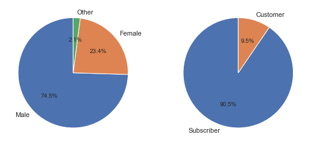

```python
plt.figure(figsize = [9, 6])
plt.subplot(1,2,1)
sorted_gender = df_clean['member_gender'].value_counts()
plt.pie(sorted_gender, labels=sorted_gender.index, startangle = 90, autopct = '%1.1f%%')

plt.subplot(1,2,2)
sorted_type = df_clean['user_type'].value_counts()
plt.pie(sorted_type, labels = sorted_type.index, startangle = 90, autopct = '%1.1f%%');
```

> **Observatio : There are two types of users, customer and subscriber, and between them there is a difference of about 80 percent There are also three types of gender, with a big difference for males**

**Distribution of bike rides according to weekday,hour**

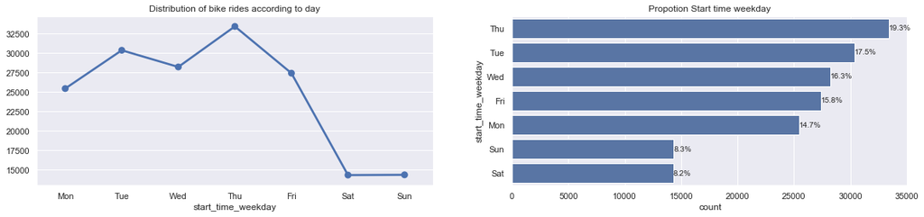

```python
# distribution weekday
plt.figure(figsize=[20,4])
plt.subplot(1,2,1)
count_day = df_clean.groupby('start_time_weekday').size()
weekday = ['Mon', 'Tue', 'Wed', 'Thu', 'Fri', 'Sat', 'Sun']
color = sns.color_palette()[0]
sns.pointplot(data = df_clean, x = count_day.index, y = count_day , color = color , order = weekday);
plt.title("Distribution of bike rides according to day");

plt.subplot(1, 2, 2)
count_value = df_clean['start_time_weekday'].value_counts()
sns.countplot(data = df_clean, y='start_time_weekday', color=color, order= count_value.index);
plt.title('Propotion Start time weekday')
print_presentation(count_value , count_value.sum())
```

> **Observation : It is clear that there is a noticeable increase during the days of the week, with a decrease only on Saturday and Sunday, with a difference of about eight percent from the average participation of degrees during the days of the week, which indicates the use of the system during working days more than during holidays**

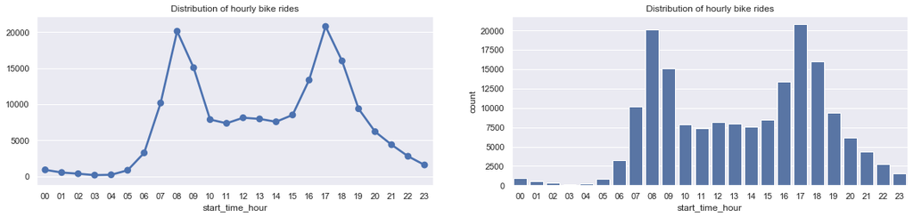

```python
#distribution to hour
plt.figure(figsize=[20,4])
plt.subplot(1,2,1)
count_hour = df_clean.groupby('start_time_hour').size()
sns.pointplot(data = df_clean,x =count_hour.index ,y=count_hour, color=color)
plt.title("Distribution of hourly bike rides")

plt.subplot(1,2,2)
sns.countplot(data=df_clean , x='start_time_hour', color=color);
plt.title("Distribution of hourly bike rides");
```

> **Observation :It is clear that there is a wave of rise during the early hours of the morning, specifically from seven to nine in the morning, then there is a decline with stability until another wave comes at the end of the work day, specifically from four in the evening until six in the evening. This also indicates that the system of participation Grades are in best condition during the first hours of work and with the end of work time**

```python
df_clean['duration_min'].describe(percentiles=[0.99])
```

```
count    173467.000000
mean         11.242905
std          27.446221
min           1.000000
50%           8.000000
99%          52.000000
max        1409.000000
Name: duration_min, dtype: float64
```

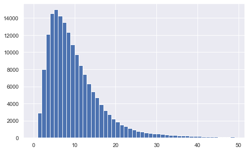

```python
# Explore the duration of backpackers
plt.figure(figsize=[8,5])
bins = np.arange(0, 50, 1)
plt.hist(data = df_clean, x = 'duration_min', bins = bins);
ticks = [0, 5, 10, 15, 20, 25, 30,  35 , 40, 45, 50]
labels = ['{}'.format(i) for i in ticks]
```

**Explore Top ten start stations vs Top ten end stations**

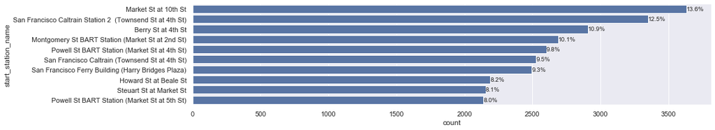

```python
plt.figure(figsize=[15,3])
color = sns.color_palette()[0]
start_order = df_clean['start_station_name'].value_counts().nlargest(10)
df_start = df_clean.loc[df_clean['start_station_name'].isin(start_order.index)]
sns.countplot(data = df_start, y = 'start_station_name', order = start_order.index, color = color);
print_presentation(start_order , start_order.sum())
```

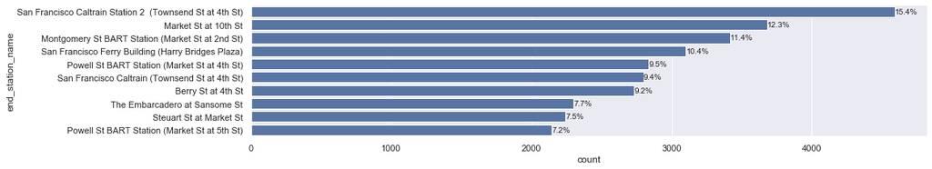

```python
plt.figure(figsize=[15,3])
end_order = df_clean['end_station_name'].value_counts().nlargest(10)
df_end = df_clean.loc[df_clean['end_station_name'].isin(end_order.index)]
sns.countplot(data = df_end, y = 'end_station_name', order = end_order.index, color = color);
print_presentation(end_order , end_order.sum())
```

> **Observation : Here are the stations that receive a heavy turnout during the start and end of voyages. This information can be used to increase the number of rungs in these stations to avoid any congestion that may occur in these stations**

```python
# take a look at the statistics of the member_age
df_clean['member_age'].describe()
```

```
count    173467.000000
mean         34.825333
std           9.376947
min          19.000000
25%          28.000000
50%          33.000000
75%          40.000000
max          65.000000
Name: member_age, dtype: float64
```

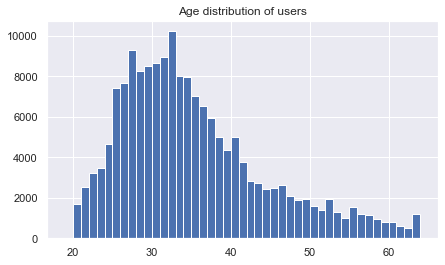

```python
# distribution age
plt.figure(figsize=[7,4])
bins = np.arange(19, 65, 1)
plt.hist(df_clean['member_age'], bins = bins );
plt.title('Age distribution of users');
```

> **Observation : The age distribution shows that most of the employees fall into the category between the ages of 25 to the age of 45, and this also corresponds to the same characteristics of adult workers**

#### Discuss the distribution(s) of your variable(s) of interest. Were there any unusual points? Did you need to perform any transformations?

> Here there were extreme values for the flight time, after converting it from the second format to the time per minute. It turns out that there are trips that take 24 hours, and this is strange when 99 percent of travelers are no more than 50 minutes. Outliers for age have also been removed

## Bivariate Exploration

> In this section, investigate relationships between pairs of variables in your data. Make sure the variables that you cover here have been introduced in some fashion in the previous section (univariate exploration).

```python
# The number and percentage of employees in each gender
count_user = df_clean.groupby('user_type')['member_gender'].count()
print(count_user, '\n')
print(count_user[0]/count_user.sum()*100)
print(count_user[1]/count_user.sum()*100)
```

```
user_type
Customer       16547
Subscriber    156920
Name: member_gender, dtype: int64

9.538990124922895
90.46100987507711
```

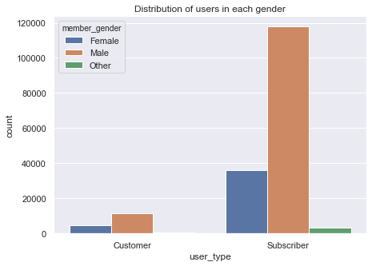

```python
plt.figure(figsize=[7,5])
sns.countplot(data =df_clean , x='user_type', hue='member_gender')
plt.title('Distribution of users in each gender');
```

> **Observation : It is clear that males use the system more than females and the other in each of the two types of users**

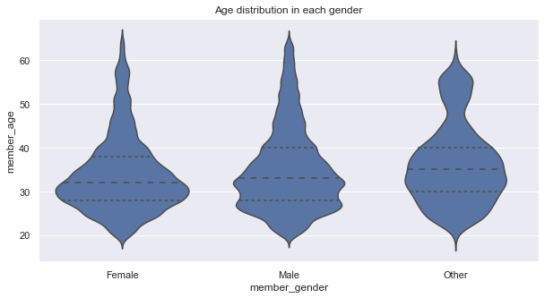

```python
# check relation between gender and age to try to find the average male/female age in the dataset
plt.figure(figsize=[10,5])
sns.violinplot(data = df_clean, x = 'member_gender', y = 'member_age', color = color, inner='quartile');
plt.title('Age distribution in each gender');
```

> **Observation : Although Males represent 75% of the dataset, the plot show the average age for males and females are quite equal around 33 years of age**

```python
# summary statistics
df_clean.groupby('user_type')['member_age'].describe()
```

| user_type | count | mean | std | min | 25% | 50% | 75% | max |
| --- | --- | --- | --- | --- | --- | --- | --- | --- |
| Customer | 16547.0 | 34.441591 | 9.033114 | 19.0 | 28.0 | 33.0 | 39.0 | 65.0 |
| Subscriber | 156920.0 | 34.865798 | 9.411588 | 19.0 | 28.0 | 33.0 | 40.0 | 65.0 |

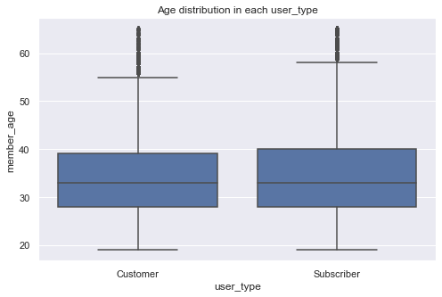

```python
# check relation between user_type and age to try to find the average male/female age in the dataset
plt.figure(figsize=[8,5])
sns.boxplot(data = df_clean, x = 'user_type', y = 'member_age', color = color);
plt.title('Age distribution in each user_type');
```

> **observation : It can be seen that the age distribution of customers is relatively less than that of the subscribers This has an effect on the trend that will appear in the following figure**

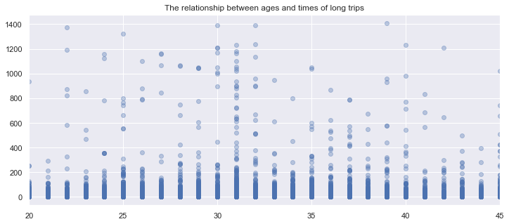

```python
# relation between age and ride duration
plt.figure(figsize = [12,5])
plt.scatter(data= df_clean , x = 'member_age', y = 'duration_min', alpha = 1/3)
plt.title('The relationship between ages and times of long trips')
plt.xlim((20,45));
```

> **Observation : We notice from the graph that the longest tours are usually conducted by people between the ages of 25 and 35. This distribution can coincide with the age distribution for the customers, as we mentioned before, and this can be interpreted as the customers usually take longer than the subscribers in the trips, and this indicates that the customers can be some tourists from outside the country enjoying spending longer time in spending trips**

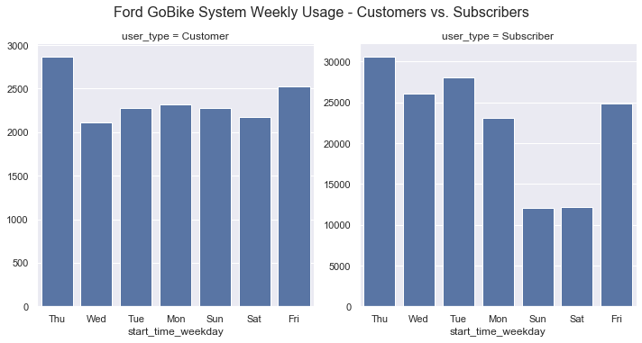

```python
# The relationship between renting stairs during weekdays and the type of tenant
g = sns.FacetGrid(data = df_clean, col='user_type', size=5 , sharey=False)
g.map(sns.countplot, 'start_time_weekday')
plt.suptitle('Ford GoBike System Weekly Usage - Customers vs. Subscribers', y=1.05, fontsize=16);
```

## Multivariate Exploration

> Create plots of three or more variables to investigate your data even further. Make sure that your investigations are justified, and follow from your work in the previous sections.

```python
# Average duration of trips per user
df_clean.groupby('user_type')['duration_min'].mean()
```

```
user_type
Customer      21.324651
Subscriber    10.179799
Name: duration_min, dtype: float64
```

[figure not shown]

```python
# relation between age and ride duration and user type
plt.figure(figsize=[20,4])
plt.subplot(1,2,1)
df_customer = df_clean.query("user_type=='Customer'")
sns.regplot(data = df_clean,x ='member_age',y= 'duration_min',scatter_kws={'alpha' :3/10}, truncate=False, x_jitter=0.1)
plt.xlabel('Age')
plt.ylabel ('Ride duration in Min')
plt.title("Customer")

plt.subplot(1,2,2)
df_subscriber = df_clean.query("user_type=='Subscriber'")
sns.regplot(data = df_subscriber,x ='member_age',y= 'duration_min',scatter_kws={'alpha' :3/10}, truncate=False, x_jitter=0.1)
plt.xlabel('Age')
plt.ylabel ('Ride duration in Min')
plt.title("Subscribe")
plt.suptitle('The relationship between age user and times of long trips', y=1.05, fontsize=16);
```

> **Observation : Confirmation of the idea that customers spend on average more time on trips than their subscribers' counterparts. This confirms the idea that customers are tourists or riders who make these trips for the sake of enjoying or exercising and that the participants are workers and students**

#### Talk about some of the relationships you observed in this part of the investigation. Were there features that strengthened each other in terms of looking at your feature(s) of interest?

> I have emphasized the strength of the relationship that says that customers spend on average more time on trips than their subscribers' counterparts. This confirms the idea that customers are tourists or riders who take these trips for the sake of enjoyment or exercise and that the participants are from the class of workers and students

#### Were there any interesting or surprising interactions between features?

> It was very interesting And that is that the number of subscribers who consumed degrees was more than the number of customers. However, customers spend more time traveling, which means customers take longer trips than subscribers

```python
# save  data clean
df_clean.to_csv("Downloads/data/Visualization/fordgobike-clean.csv", index=False)
```